# Data Wrangling

Alexander Poon alex.poon@tn.gov

January 05, 2018

## Table of contents

- Looking at a data frame
- Keeping/dropping variables
- Reordering variables
- Keeping/dropping observations
- Creating/modifying variables
- Creating/modifying variables conditionally
- The pipe operator
- Renaming variables
- Sorting
- Creating a data frame of summary statistics
- Aggregating data by group
- Add summary statistics to a data frame
- Operations by row
- Combining data frames
- Reshaping

## The `tidyverse`

The `tidyverse` is a set of packages which covers most steps of the data science process (importing, wrangling, visualization).

[figure not shown]

- Built around the concept of a **tidy** data frame
- Work nicely with the **pipe** `%>%`

## Obtaining the `tidyverse`

Install the `tidyverse` packages and their dependencies:

`install.packages("tidyverse")`

Import the core `tidyverse` packages into your R session:

`library(tidyverse)`

## Reading in data

Use `readr::read_csv()` to import a .csv file:

```r
ach_profile <- read_csv("data/achievement_profile_data_with_CORE.csv")
```

## Our data

For each of 145 TN school districts and the State, the `ach_profile` data contains:

- Proficiency rates on state tests
- Student demographics
- Chronic absenteeism
- Discipline (suspension, expulsion) rates
- High school graduation, dropout rates
- Average ACT composite scores
- A region variable

for the 2014-15 school year.

## Looking at data

Use `View()` to look at a data frame:

```r
View(ach_profile)
```

## Looking at data

The RStudio viewer has features for sorting and filtering:

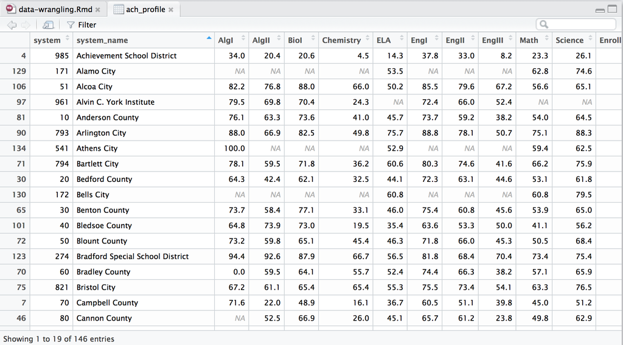

## Looking at data

The RStudio viewer has features for sorting and filtering:

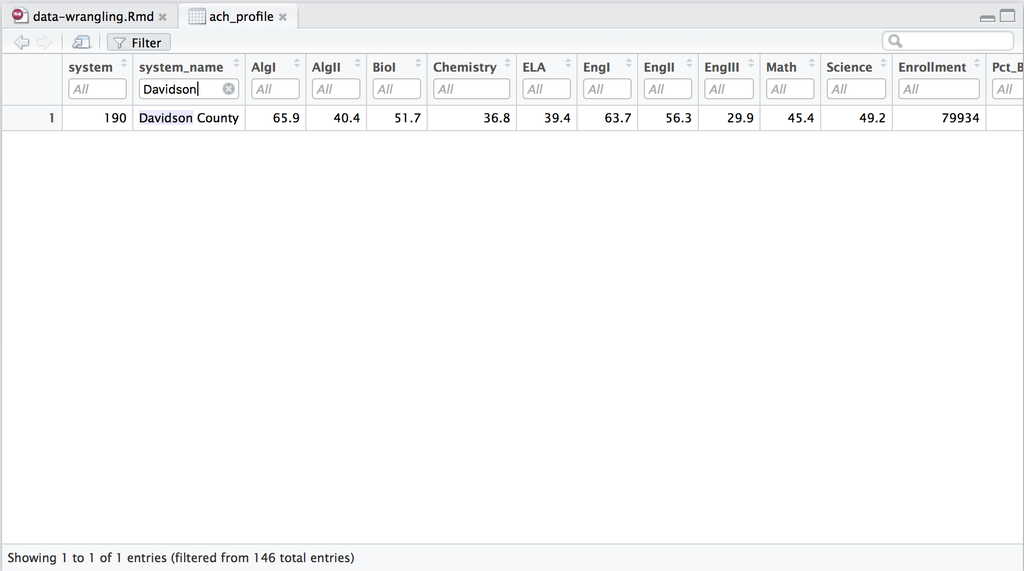

## An overview of a data frame

Use `summary()` to get an overview of a data frame:

```r
summary(ach_profile)
```

```
##      system      system_name             AlgI
##  Min.   :  0.0   Length:146         Min.   :  0.00
##  1st Qu.:212.5   Class :character   1st Qu.: 62.25
##  Median :485.0   Mode  :character   Median : 72.40
##  Mean   :480.5                      Mean   : 69.26
##  3rd Qu.:757.8                      3rd Qu.: 79.35
##  Max.   :985.0                      Max.   :100.00
##                                     NA's   :18
##      AlgII            BioI          Chemistry          ELA
##  Min.   : 0.00   Min.   : 11.80   Min.   : 0.00   Min.   : 0.0
##  1st Qu.:43.55   1st Qu.: 59.30   1st Qu.:33.20   1st Qu.:42.6
##  Median :57.40   Median : 68.90   Median :43.90   Median :47.5
##  Mean   :55.47   Mean   : 66.47   Mean   :44.17   Mean   :47.4
##  3rd Qu.:67.95   3rd Qu.: 74.50   3rd Qu.:54.45   3rd Qu.:53.6
##  Max.   :92.60   Max.   :100.00   Max.   :86.10   Max.   :83.2
##  NA's   :23      NA's   :17       NA's   :19      NA's   :1
##       EngI           EngII           EngIII           Math
##  Min.   : 0.00   Min.   : 6.70   Min.   : 0.00   Min.   : 0.00
##  1st Qu.:67.50   1st Qu.:58.55   1st Qu.:36.30   1st Qu.:48.00
##  Median :72.90   Median :66.15   Median :44.00   Median :55.20
##  Mean   :71.86   Mean   :64.65   Mean   :43.72   Mean   :54.36
##  3rd Qu.:77.40   3rd Qu.:71.40   3rd Qu.:51.20   3rd Qu.:62.00
##  Max.   :92.90   Max.   :88.70   Max.   :72.20   Max.   :88.20
##  NA's   :17      NA's   :18      NA's   :17      NA's   :1
##     Science        Enrollment       Pct_Black
##  Min.   : 0.00   Min.   :   270   Min.   : 0.100
##  1st Qu.:59.50   1st Qu.:  1660   1st Qu.: 2.725
##  Median :66.50   Median :  3456   Median : 6.250
##  Mean   :64.97   Mean   : 13291   Mean   :12.910
##  3rd Qu.:72.50   3rd Qu.:  6354   3rd Qu.:16.250
##  Max.   :91.10   Max.   :943699   Max.   :96.700
##  NA's   :1       NA's   :4
##   Pct_Hispanic    Pct_Native_American     Pct_EL
##  Min.   : 0.000   Min.   :0.0000      Min.   : 0.000
##  1st Qu.: 2.100   1st Qu.:0.2000      1st Qu.: 0.125
##  Median : 4.050   Median :0.3000      Median : 0.950
##  Mean   : 5.655   Mean   :0.3116      Mean   : 2.115
##  3rd Qu.: 7.700   3rd Qu.:0.4000      3rd Qu.: 2.775
##  Max.   :25.300   Max.   :1.2000      Max.   :16.200
##
```

[output cut: 17 more lines]

```
##  Min.   : 0.000   Min.   :0.00000   Min.   :  0.00
##  1st Qu.: 0.525   1st Qu.:0.00000   1st Qu.: 87.35
##  Median : 2.200   Median :0.00000   Median : 91.20
##  Mean   : 2.901   Mean   :0.06507   Mean   : 88.00
##  3rd Qu.: 4.275   3rd Qu.:0.10000   3rd Qu.: 94.60
##  Max.   :21.400   Max.   :0.80000   Max.   :100.00
##                                     NA's   :14
##     Dropout        CORE_region
##  Min.   :  0.000   Length:146
##  1st Qu.:  3.000   Class :character
##  Median :  5.300   Mode  :character
##  Mean   :  6.603
##  3rd Qu.:  7.925
##  Max.   :100.000
##  NA's   :14
```

## An overview of a data frame

Use `tibble::glimpse()` to get an overview of a data frame:

```r
glimpse(ach_profile)
```

```
## Observations: 146
## Variables: 28
## $ system                 <int> 0, 10, 11, 12, 20, 30, 40, 50...
## $ system_name            <chr> "State of Tennessee", "Anders...
## $ AlgI                   <dbl> 70.0, 76.1, NA, 76.9, 64.3, 7...
## $ AlgII                  <dbl> 54.3, 63.3, NA, 72.0, 42.4, 5...
## $ BioI                   <dbl> 65.3, 73.6, NA, 83.5, 62.1, 7...
## $ Chemistry              <dbl> 44.2, 41.0, NA, 80.9, 32.5, 3...
## $ ELA                    <dbl> 48.4, 45.7, 58.3, 56.1, 44.1,...
## $ EngI                   <dbl> 71.8, 73.7, NA, 86.7, 72.3, 7...
## $ EngII                  <dbl> 64.8, 59.2, NA, 74.6, 63.1, 6...
## $ EngIII                 <dbl> 41.7, 38.2, NA, 53.8, 44.6, 4...
## $ Math                   <dbl> 54.7, 54.0, 68.9, 55.3, 53.1,...
## $ Science                <dbl> 64.5, 64.5, 69.6, 70.8, 61.8,...
## $ Enrollment             <int> 943699, 6304, 894, 4326, 8270...
## $ Pct_Black              <dbl> 24.1, 2.8, 5.7, 16.6, 11.2, 3...
## $ Pct_Hispanic           <dbl> 8.5, 1.1, 2.8, 8.0, 20.6, 2.1...
## $ Pct_Native_American    <dbl> 0.3, 0.5, 0.3, 0.7, 0.5, 0.3,...
## $ Pct_EL                 <dbl> 4.6, 0.2, 1.0, 3.0, 9.4, 0.0,...
## $ Pct_SWD                <dbl> 14.0, 18.0, 18.1, 14.3, 10.9,...
## $ Pct_ED                 <dbl> 57.9, 58.5, 63.4, 52.5, 69.9,...
## $ Per_Pupil_Expenditures <dbl> 9374.9, 9535.7, 9537.5, 12355...
## $ Pct_BHN                <dbl> 32.9, 4.4, 8.8, 25.3, 32.3, 6...
## $ ACT_Composite          <dbl> 19.4, 19.9, NA, 23.1, 18.4, 1...
## $ Pct_Chronically_Absent <dbl> 13.2, 11.5, 8.8, 17.5, 8.6, 6...
## $ Pct_Suspended          <dbl> 6.2, 5.0, 1.2, 5.7, 2.2, 0.0,...
## $ Pct_Expelled           <dbl> 0.2, 0.1, 0.0, 0.0, 0.0, 0.0,...
## $ Graduation             <dbl> 87.2, 94.0, NA, 89.7, 90.8, 9...
## $ Dropout                <dbl> 8.4, 4.2, NA, 4.4, 5.4, 3.0, ...
## $ CORE_region            <chr> NA, "East TN CORE", "East TN ...
```

## `dplyr` and `tidyr`

Your two-stop shop for data wrangling:

`dplyr`: pliers, for data frames

## `dplyr`

Five main functions:

- `select()`
- `filter()`
- `mutate()`
- `arrange()`
- `summarise()`

## Keeping/dropping variables

Keep variables with `select()`:

```r
select(ach_profile, system, system_name)
```

The first argument to `select()` is a data frame, and the second is the variable(s) you want to keep, separated by commas.

## Keeping/dropping variables

Keep variables with `select()`:

```r
select(ach_profile, system, system_name)
```

```
## # A tibble: 146 x 2
##    system        system_name
##     <int>              <chr>
##  1      0 State of Tennessee
##  2     10    Anderson County
##  3     11       Clinton City
##  4     12     Oak Ridge City
##  5     20     Bedford County
##  6     30      Benton County
##  7     40     Bledsoe County
##  8     50      Blount County
##  9     51         Alcoa City
## 10     52     Maryville City
## # ... with 136 more rows
```

## Keeping/dropping variables

Drop variables with `select()` using `-` before a variable name:

```r
select(ach_profile, -system)
```

```
## # A tibble: 146 x 27
##           system_name  AlgI AlgII  BioI Chemistry   ELA  EngI
##                 <chr> <dbl> <dbl> <dbl>     <dbl> <dbl> <dbl>
##  1 State of Tennessee  70.0  54.3  65.3      44.2  48.4  71.8
##  2    Anderson County  76.1  63.3  73.6      41.0  45.7  73.7
##  3       Clinton City    NA    NA    NA        NA  58.3    NA
##  4     Oak Ridge City  76.9  72.0  83.5      80.9  56.1  86.7
##  5     Bedford County  64.3  42.4  62.1      32.5  44.1  72.3
##  6      Benton County  73.7  58.4  77.1      33.1  46.0  75.4
##  7     Bledsoe County  64.8  73.9  73.0      19.5  35.4  63.6
##  8      Blount County  73.2  59.8  65.1      45.4  46.3  71.8
##  9         Alcoa City  82.2  76.8  88.0      66.0  50.2  85.5
## 10     Maryville City  83.8  77.3  92.1      80.4  69.6  89.9
## # ... with 136 more rows, and 20 more variables: EngII <dbl>,
## #   EngIII <dbl>, Math <dbl>, Science <dbl>, Enrollment <int>,
## #   Pct_Black <dbl>, Pct_Hispanic <dbl>,
## #   Pct_Native_American <dbl>, Pct_EL <dbl>, Pct_SWD <dbl>,
## #   Pct_ED <dbl>, Per_Pupil_Expenditures <dbl>, Pct_BHN <dbl>,
## #   ACT_Composite <dbl>, Pct_Chronically_Absent <dbl>,
## #   Pct_Suspended <dbl>, Pct_Expelled <dbl>, Graduation <dbl>,
## #   Dropout <dbl>, CORE_region <chr>
```

## Ways to call variables with `select`

- Unquoted names - `select(df, x, y, z)`
- A range of variables positionally - `select(df, x:z)`
- Using `dplyr` helper functions, including:
  - `starts_with()`
  - `ends_with()`
  - `contains()`
  - `one_of()` if you need to specify variables as a string
  - `everything()`

## Reordering variables

Reorder variables with `select()` by listing variables in the order you want:

```r
select(ach_profile, system, system_name, CORE_region, everything())
```

```
## # A tibble: 146 x 28
##    system        system_name           CORE_region  AlgI AlgII
##     <int>              <chr>                 <chr> <dbl> <dbl>
##  1      0 State of Tennessee                  <NA>  70.0  54.3
##  2     10    Anderson County          East TN CORE  76.1  63.3
##  3     11       Clinton City          East TN CORE    NA    NA
##  4     12     Oak Ridge City          East TN CORE  76.9  72.0
##  5     20     Bedford County    South Central CORE  64.3  42.4
##  6     30      Benton County        Northwest CORE  73.7  58.4
##  7     40     Bledsoe County Upper Cumberland CORE  64.8  73.9
##  8     50      Blount County          East TN CORE  73.2  59.8
##  9     51         Alcoa City          East TN CORE  82.2  76.8
## 10     52     Maryville City          East TN CORE  83.8  77.3
## # ... with 136 more rows, and 23 more variables: BioI <dbl>,
## #   Chemistry <dbl>, ELA <dbl>, EngI <dbl>, EngII <dbl>,
## #   EngIII <dbl>, Math <dbl>, Science <dbl>, Enrollment <int>,
## #   Pct_Black <dbl>, Pct_Hispanic <dbl>,
## #   Pct_Native_American <dbl>, Pct_EL <dbl>, Pct_SWD <dbl>,
## #   Pct_ED <dbl>, Per_Pupil_Expenditures <dbl>, Pct_BHN <dbl>,
## #   ACT_Composite <dbl>, Pct_Chronically_Absent <dbl>,
## #   Pct_Suspended <dbl>, Pct_Expelled <dbl>, Graduation <dbl>,
## #   Dropout <dbl>
```

## Keeping/dropping observations

Keep observations with `filter()`:

```r
filter(ach_profile, system_name == "State of Tennessee")
```

The first argument to `filter()` is a data frame, and the second is a logical condition describing the observations you want to keep.

## Keeping/dropping observations

Keep observations with `filter()`:

```r
filter(ach_profile, system_name == "State of Tennessee")
```

```
## # A tibble: 1 x 28
##   system        system_name  AlgI AlgII  BioI Chemistry   ELA
##    <int>              <chr> <dbl> <dbl> <dbl>     <dbl> <dbl>
## 1      0 State of Tennessee    70  54.3  65.3      44.2  48.4
## # ... with 21 more variables: EngI <dbl>, EngII <dbl>,
## #   EngIII <dbl>, Math <dbl>, Science <dbl>, Enrollment <int>,
## #   Pct_Black <dbl>, Pct_Hispanic <dbl>,
## #   Pct_Native_American <dbl>, Pct_EL <dbl>, Pct_SWD <dbl>,
## #   Pct_ED <dbl>, Per_Pupil_Expenditures <dbl>, Pct_BHN <dbl>,
## #   ACT_Composite <dbl>, Pct_Chronically_Absent <dbl>,
## #   Pct_Suspended <dbl>, Pct_Expelled <dbl>, Graduation <dbl>,
## #   Dropout <dbl>, CORE_region <chr>
```

## Keeping/dropping observations

Drop observations with `filter()` by negating a logical condition:

```r
filter(ach_profile, system_name != "State of Tennessee")
```

```
## # A tibble: 145 x 28
##    system     system_name  AlgI AlgII  BioI Chemistry   ELA
##     <int>           <chr> <dbl> <dbl> <dbl>     <dbl> <dbl>
##  1     10 Anderson County  76.1  63.3  73.6      41.0  45.7
##  2     11    Clinton City    NA    NA    NA        NA  58.3
##  3     12  Oak Ridge City  76.9  72.0  83.5      80.9  56.1
##  4     20  Bedford County  64.3  42.4  62.1      32.5  44.1
##  5     30   Benton County  73.7  58.4  77.1      33.1  46.0
##  6     40  Bledsoe County  64.8  73.9  73.0      19.5  35.4
##  7     50   Blount County  73.2  59.8  65.1      45.4  46.3
##  8     51      Alcoa City  82.2  76.8  88.0      66.0  50.2
##  9     52  Maryville City  83.8  77.3  92.1      80.4  69.6
## 10     60  Bradley County   0.0  59.5  64.1      55.7  52.4
## # ... with 135 more rows, and 21 more variables: EngI <dbl>,
## #   EngII <dbl>, EngIII <dbl>, Math <dbl>, Science <dbl>,
## #   Enrollment <int>, Pct_Black <dbl>, Pct_Hispanic <dbl>,
## #   Pct_Native_American <dbl>, Pct_EL <dbl>, Pct_SWD <dbl>,
## #   Pct_ED <dbl>, Per_Pupil_Expenditures <dbl>, Pct_BHN <dbl>,
## #   ACT_Composite <dbl>, Pct_Chronically_Absent <dbl>,
## #   Pct_Suspended <dbl>, Pct_Expelled <dbl>, Graduation <dbl>,
## #   Dropout <dbl>, CORE_region <chr>
```

## Exercise 1

Use `filter()` to identify districts with 100% Algebra I proficiency.

```r
filter(ach_profile, AlgI == 100)
```

```
## # A tibble: 4 x 28
##   system                      system_name  AlgI AlgII  BioI
##    <int>                            <chr> <dbl> <dbl> <dbl>
## 1    401    Paris Special School District   100    NA    NA
## 2    541                      Athens City   100    NA    NA
## 3    941 Franklin Special School District   100    NA    NA
## 4    951  Lebanon Special School District   100    NA    NA
## # ... with 23 more variables: Chemistry <dbl>, ELA <dbl>,
## #   EngI <dbl>, EngII <dbl>, EngIII <dbl>, Math <dbl>,
## #   Science <dbl>, Enrollment <int>, Pct_Black <dbl>,
## #   Pct_Hispanic <dbl>, Pct_Native_American <dbl>, Pct_EL <dbl>,
## #   Pct_SWD <dbl>, Pct_ED <dbl>, Per_Pupil_Expenditures <dbl>,
## #   Pct_BHN <dbl>, ACT_Composite <dbl>,
## #   Pct_Chronically_Absent <dbl>, Pct_Suspended <dbl>,
## #   Pct_Expelled <dbl>, Graduation <dbl>, Dropout <dbl>,
## #   CORE_region <chr>
```

## Creating new variables

Create new variables with `mutate()`:

```r
mutate(ach_profile,
    Pct_BHN = Pct_Black + Pct_Hispanic + Pct_Native_American)
```

The first argument to `mutate()` is a data frame, and the second is a new variable name followed by `=` and an expression for calculating that variable.

## Modifying variables

The syntax for modifying variables with `mutate()` is the same as for creating variables:

```r
mutate(ach_profile, Enrollment = Enrollment/1000)
```

## Creating/modifying variables

Create and/or modify arbitrarily many variables with `mutate()`; separate expressions with a comma:

```r
mutate(ach_profile, Enrollment = Enrollment/1000,
    Per_Pupil_Expenditures = Per_Pupil_Expenditures/1000)
```

## `if_else()` with `mutate()`

Use `if_else()` if you want a variable to take different values under different conditions:

```r
mutate(ach_profile,
    district_size = if_else(Enrollment >= 10000, "Large", "Small"))
```

- The first argument to `if_else()` is a logical condition.
- The second is the value of the new variable if the logical condition is `TRUE`.
- The third is the value of the variable if the logical condition is `FALSE`.
- If the logical condition returns `NA`, the value of the variable will be `NA`.

## `if_else()` with `mutate()`

Use `if_else()` if you want a variable to take different values under different conditions:

```r
mutate(ach_profile,
    district_size = if_else(Enrollment >= 10000, "Large", "Small"))
```

```
## # A tibble: 146 x 3
##           system_name Enrollment district_size
##                 <chr>      <int>         <chr>
##  1 State of Tennessee     943699         Large
##  2    Anderson County       6304         Small
##  3       Clinton City        894         Small
##  4     Oak Ridge City       4326         Small
##  5     Bedford County       8270         Small
##  6      Benton County       2133         Small
##  7     Bledsoe County       1674         Small
##  8      Blount County      10500         Large
##  9         Alcoa City       1850         Small
## 10     Maryville City       4944         Small
## # ... with 136 more rows
```

## `if_else()` with `mutate()`

Use multiple `if_else()` statements in succession if you have multiple conditions:

```r
mutate(ach_profile,
    district_size = if_else(Enrollment >= 10000, "Large", NA_character_),
    district_size = if_else(Enrollment >= 5000 & Enrollment < 10000,
        "Medium", district_size),
    district_size = if_else(Enrollment < 5000, "Small", district_size)
)
```

The first `if_else()` assigns a value of `"Large"` to `district_size` if `Enrollment` is greater or equal to 10000, and `NA` (of the character variety) otherwise.

## `if_else()` with `mutate()`

Use multiple `if_else()` statements in succession if you have multiple conditions:

```r
mutate(ach_profile,
    district_size = if_else(Enrollment >= 10000, "Large", NA_character_),
    district_size = if_else(Enrollment >= 5000 & Enrollment < 10000,
        "Medium", district_size),
    district_size = if_else(Enrollment < 5000, "Small", district_size)
)
```

The second `if_else()` assigns a value of `"Medium"` to `district_size` if `Enrollment` is between 5000 and 10000, and leaves `district_size` the same otherwise.

## `if_else()` with `mutate()`

Use multiple `if_else()` statements in succession if you have multiple conditions:

```r
mutate(ach_profile,
    district_size = if_else(Enrollment >= 10000, "Large", NA_character_),
    district_size = if_else(Enrollment >= 5000 & Enrollment < 10000,
        "Medium", district_size),
    district_size = if_else(Enrollment < 5000, "Small", district_size)
)
```

The third `if_else()` assigns a value of `"Small"` to `district_size` if `Enrollment` is less than 5000, and leaves `district_size` the same otherwise.

## `if_else()` with `mutate()`

```r
mutate(ach_profile,
    district_size = if_else(Enrollment >= 10000, "Large", NA_character_),
    district_size = if_else(Enrollment >= 5000 & Enrollment < 10000,
        "Medium", district_size),
    district_size = if_else(Enrollment < 5000, "Small", district_size)
)
```

```
## # A tibble: 146 x 3
##           system_name Enrollment district_size
##                 <chr>      <int>         <chr>
##  1 State of Tennessee     943699         Large
##  2    Anderson County       6304        Medium
##  3       Clinton City        894         Small
##  4     Oak Ridge City       4326         Small
##  5     Bedford County       8270        Medium
##  6      Benton County       2133         Small
##  7     Bledsoe County       1674         Small
##  8      Blount County      10500         Large
##  9         Alcoa City       1850         Small
## 10     Maryville City       4944         Small
## # ... with 136 more rows
```

## `case_when()` with `mutate()`

With many conditions, it’s better to use `case_when()` than several `if_else()` statements:

```r
mutate(ach_profile,
    district_size = case_when(
        Enrollment >= 10000 ~ "Large",
        Enrollment >= 5000 ~ "Medium",
        Enrollment < 5000 ~ "Small"
    )
)
```

The argument to `case_when()` is a sequence of two-sided formulas, where the left side of each formula is a logical condition, and the right side is the value of a variable if the logical condition is `TRUE`.

## `case_when()` with `mutate()`

With many conditions, it’s better to use `case_when` than several `if_else` statements:

```r
mutate(ach_profile,
    district_size = case_when(
        Enrollment >= 10000 ~ "Large",
        Enrollment >= 5000 ~ "Medium",
        Enrollment < 5000 ~ "Small"
    )
)
```

Each logical condition in `case_when()` is evaluated as IF (condition) AND NOT (any previous condition), so consider this when specifying/ordering your formulas.

## Exercise 2

Create a new variable called `math_achievement` with a value of:

- `"High"` if a district’s Math proficiency is 75% or higher;
- `"Medium"` if a district’s Math proficiency is between 50% and 75%;
- `"Low"` if a district’s Math proficiency is below 50%.

```r
mutate(ach_profile,
    math_achievement = if_else(Math >= 75, "High", NA_character_),
    math_achievement = if_else(Math >= 50 & Math < 75, "Medium", math_achievement),
    math_achievement = if_else(Math < 50, "Low", math_achievement)
)
```

## Exercise 2

Create a new variable called `math_achievement` with a value of:

- `"High"` if a district’s Math proficiency is 75% or higher;
- `"Medium"` if a district’s Math proficiency is between 50% and 75%;
- `"Low"` if a district’s Math proficiency is below 50%.

```r
mutate(ach_profile,
    math_achievement = case_when(
        Math >= 75 ~ "High",
        Math >= 50 ~ "Medium",
        Math < 50 ~ "Low"
    )
)
```

## Exercise 2

Create a new variable called `math_achievement` with a value of:

- `"High"` if a district’s Math proficiency is 75% or higher;
- `"Medium"` if a district’s Math proficiency is between 50% and 75%;
- `"Low"` if a district’s Math proficiency is below 50%.

```
## # A tibble: 146 x 3
##           system_name  Math math_achievement
##                 <chr> <dbl>            <chr>
##  1 State of Tennessee  54.7           Medium
##  2    Anderson County  54.0           Medium
##  3       Clinton City  68.9           Medium
##  4     Oak Ridge City  55.3           Medium
##  5     Bedford County  53.1           Medium
##  6      Benton County  53.9           Medium
##  7     Bledsoe County  41.1              Low
##  8      Blount County  50.5           Medium
##  9         Alcoa City  56.6           Medium
## 10     Maryville City  70.2           Medium
## # ... with 136 more rows
```

## The pipe operator (`%>%`)

Often, you will want to do several data manipulations in succession. This can be a hassle if you have to nest a bunch of function calls:

```r
mutate(
    select(
        filter(ach_profile, system_name != "State of Tennessee"),
    system_name, Enrollment:Per_Pupil_Expenditures),
Enrollment = log10(Enrollment)
)
```

Or assign each intermediate step to a object:

```r
ach_profile2 <- filter(ach_profile, system_name != "State of Tennessee")
ach_profile3 <- select(ach_profile2,
    system_name, Enrollment:Per_Pupil_Expenditures)
ach_profile4 <- mutate(ach_profile3, Enrollment = log10(Enrollment))
```

## The pipe operator (`%>%`)

The pipe operator (`%>%`) provides a better alternative. It passes the result of one function as an argument to another function (the first argument, by default).

The first argument of all `dplyr` and `tidyr` functions is the data frame you want to manipulate, so piping makes for more readable code:

```r
ach_profile %>%
    filter(system_name != "State of Tennessee") %>%
    select(system_name, Enrollment:Per_Pupil_Expenditures) %>%
    mutate(Enrollment = log10(Enrollment))
```

## Exercise 3

Filter down to district 792 (Shelby County), then pipe the result to `View()`.

```r
ach_profile %>%
    filter(system == 792) %>%
    View()
```

## Exercise 3

Filter down to district 792 (Shelby County), then pipe the result to `View()`.

```r
ach_profile %>%
    filter(system == 792) %>%
    View()
```

[figure not shown]

## Renaming variables

Rename variables with `rename()`:

```r
rename(ach_profile, District = system)
```

The first argument to `rename()` is a data frame, followed by pairs of names with the pattern `new_name = old_name`.

## Renaming variables

Rename variables with `rename()`:

```r
rename(ach_profile, District = system)
```

```
## # A tibble: 146 x 28
##    District        system_name  AlgI AlgII  BioI Chemistry   ELA
##       <int>              <chr> <dbl> <dbl> <dbl>     <dbl> <dbl>
##  1        0 State of Tennessee  70.0  54.3  65.3      44.2  48.4
##  2       10    Anderson County  76.1  63.3  73.6      41.0  45.7
##  3       11       Clinton City    NA    NA    NA        NA  58.3
##  4       12     Oak Ridge City  76.9  72.0  83.5      80.9  56.1
##  5       20     Bedford County  64.3  42.4  62.1      32.5  44.1
##  6       30      Benton County  73.7  58.4  77.1      33.1  46.0
##  7       40     Bledsoe County  64.8  73.9  73.0      19.5  35.4
##  8       50      Blount County  73.2  59.8  65.1      45.4  46.3
##  9       51         Alcoa City  82.2  76.8  88.0      66.0  50.2
## 10       52     Maryville City  83.8  77.3  92.1      80.4  69.6
## # ... with 136 more rows, and 21 more variables: EngI <dbl>,
## #   EngII <dbl>, EngIII <dbl>, Math <dbl>, Science <dbl>,
## #   Enrollment <int>, Pct_Black <dbl>, Pct_Hispanic <dbl>,
## #   Pct_Native_American <dbl>, Pct_EL <dbl>, Pct_SWD <dbl>,
## #   Pct_ED <dbl>, Per_Pupil_Expenditures <dbl>, Pct_BHN <dbl>,
## #   ACT_Composite <dbl>, Pct_Chronically_Absent <dbl>,
## #   Pct_Suspended <dbl>, Pct_Expelled <dbl>, Graduation <dbl>,
## #   Dropout <dbl>, CORE_region <chr>
```

## Renaming variables

Variable names can contain spaces and other characters. Put backticks (``) around a name if it contains spaces.

```r
rename(ach_profile, District = system,
    `District Name` = system_name)
```

```
## # A tibble: 146 x 28
##    District    `District Name`  AlgI AlgII  BioI Chemistry   ELA
##       <int>              <chr> <dbl> <dbl> <dbl>     <dbl> <dbl>
##  1        0 State of Tennessee  70.0  54.3  65.3      44.2  48.4
##  2       10    Anderson County  76.1  63.3  73.6      41.0  45.7
##  3       11       Clinton City    NA    NA    NA        NA  58.3
##  4       12     Oak Ridge City  76.9  72.0  83.5      80.9  56.1
##  5       20     Bedford County  64.3  42.4  62.1      32.5  44.1
##  6       30      Benton County  73.7  58.4  77.1      33.1  46.0
##  7       40     Bledsoe County  64.8  73.9  73.0      19.5  35.4
##  8       50      Blount County  73.2  59.8  65.1      45.4  46.3
##  9       51         Alcoa City  82.2  76.8  88.0      66.0  50.2
## 10       52     Maryville City  83.8  77.3  92.1      80.4  69.6
## # ... with 136 more rows, and 21 more variables: EngI <dbl>,
## #   EngII <dbl>, EngIII <dbl>, Math <dbl>, Science <dbl>,
## #   Enrollment <int>, Pct_Black <dbl>, Pct_Hispanic <dbl>,
## #   Pct_Native_American <dbl>, Pct_EL <dbl>, Pct_SWD <dbl>,
## #   Pct_ED <dbl>, Per_Pupil_Expenditures <dbl>, Pct_BHN <dbl>,
## #   ACT_Composite <dbl>, Pct_Chronically_Absent <dbl>,
## #   Pct_Suspended <dbl>, Pct_Expelled <dbl>, Graduation <dbl>,
## #   Dropout <dbl>, CORE_region <chr>
```

## Exercise 4

Do the following in one sequence of function calls, piped together:

1. Read in the `data/tvaas.csv` file.
2. Rename variables as follows:
   - `District Number` to `system`.
   - `District-Wide: Composite` to `TVAAS Composite`.
   - `District-Wide: Literacy` to `TVAAS Literacy`.
   - `District-Wide: Numeracy` to `TVAAS Numeracy`.
3. Drop the `District Name` variable.

Assign the name `tvaas` to the result.

## Exercise 4

```r
tvaas <- read_csv("data/tvaas.csv") %>%
    rename(system = `District Number`,
           `TVAAS Composite` = `District-Wide: Composite`,
           `TVAAS Literacy` = `District-Wide: Literacy`,
           `TVAAS Numeracy` = `District-Wide: Numeracy`) %>%
    select(-`District Name`)
```

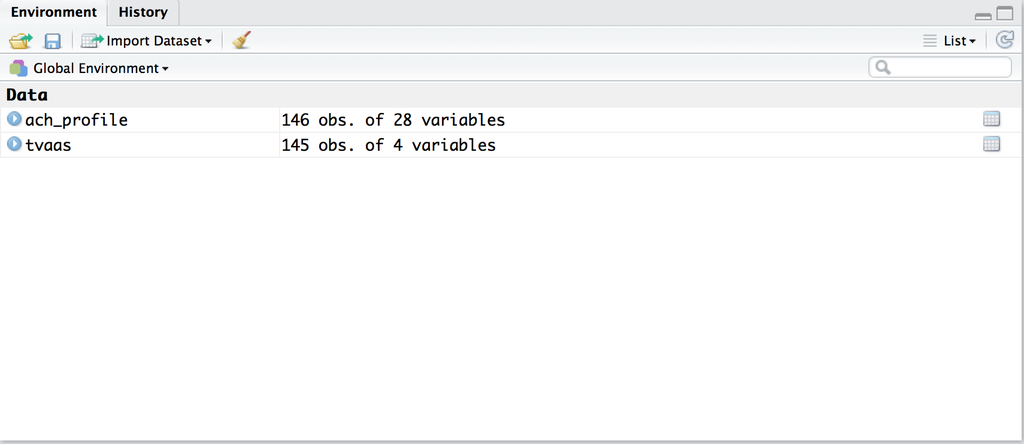

## Exercise 4

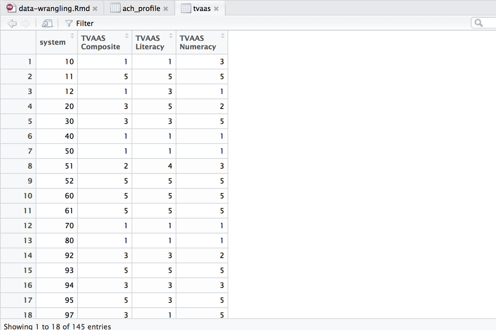

## Sorting a data frame

Sort a data frame with `arrange()`:

```r
arrange(ach_profile, system_name)
```

The first argument to `arrange()` is a data frame, and the second is the variable(s) you want to sort on.

## Sorting a data frame

Sort a data frame with `arrange()`:

```r
arrange(ach_profile, system_name)
```

```
## # A tibble: 146 x 28
##    system                 system_name  AlgI AlgII  BioI
##     <int>                       <chr> <dbl> <dbl> <dbl>
##  1    985 Achievement School District  34.0  20.4  20.6
##  2    171                  Alamo City    NA    NA    NA
##  3     51                  Alcoa City  82.2  76.8  88.0
##  4    961     Alvin C. York Institute  79.5  69.8  70.4
##  5     10             Anderson County  76.1  63.3  73.6
##  6    793              Arlington City  88.0  66.9  82.5
##  7    541                 Athens City 100.0    NA    NA
##  8    794               Bartlett City  78.1  59.5  71.8
##  9     20              Bedford County  64.3  42.4  62.1
## 10    172                  Bells City    NA    NA    NA
## # ... with 136 more rows, and 23 more variables:
## #   Chemistry <dbl>, ELA <dbl>, EngI <dbl>, EngII <dbl>,
## #   EngIII <dbl>, Math <dbl>, Science <dbl>, Enrollment <int>,
## #   Pct_Black <dbl>, Pct_Hispanic <dbl>,
## #   Pct_Native_American <dbl>, Pct_EL <dbl>, Pct_SWD <dbl>,
## #   Pct_ED <dbl>, Per_Pupil_Expenditures <dbl>, Pct_BHN <dbl>,
## #   ACT_Composite <dbl>, Pct_Chronically_Absent <dbl>,
## #   Pct_Suspended <dbl>, Pct_Expelled <dbl>, Graduation <dbl>,
## #   Dropout <dbl>, CORE_region <chr>
```

## Sorting a data frame

`arrange()` sorts numeric variables in ascending order and string variables alphabetically; reverse this with `desc(var_name)`.

```r
arrange(ach_profile, desc(system_name))
```

```
## # A tibble: 146 x 28
##    system                          system_name  AlgI AlgII  BioI
##     <int>                                <chr> <dbl> <dbl> <dbl>
##  1    950                        Wilson County  69.8  58.0  74.1
##  2    940                    Williamson County  90.3  84.8  89.2
##  3    930                         White County  80.3  58.6  82.8
##  4    960            West Tenn School for Deaf    NA    NA    NA
##  5     97 West Carroll Special School District  60.8  54.5  73.8
##  6    920                       Weakley County  79.3  64.3  81.2
##  7    910                         Wayne County  71.8  56.0  69.5
##  8    900                    Washington County  67.0  48.7  67.6
##  9    890                        Warren County    NA    NA  57.3
## 10    880                     Van Buren County  68.3  68.5  49.2
## # ... with 136 more rows, and 23 more variables:
## #   Chemistry <dbl>, ELA <dbl>, EngI <dbl>, EngII <dbl>,
## #   EngIII <dbl>, Math <dbl>, Science <dbl>, Enrollment <int>,
## #   Pct_Black <dbl>, Pct_Hispanic <dbl>,
## #   Pct_Native_American <dbl>, Pct_EL <dbl>, Pct_SWD <dbl>,
## #   Pct_ED <dbl>, Per_Pupil_Expenditures <dbl>, Pct_BHN <dbl>,
## #   ACT_Composite <dbl>, Pct_Chronically_Absent <dbl>,
## #   Pct_Suspended <dbl>, Pct_Expelled <dbl>, Graduation <dbl>,
## #   Dropout <dbl>, CORE_region <chr>
```

## Exercise 5

Sort `ach_profile` alphabetically by CORE region, then by Algebra I proficiency in descending order. Then, keep the district name, Algebra I proficiency, and CORE region variables.

```r
ach_profile %>%
    arrange(CORE_region, desc(AlgI)) %>%
    select(system_name, AlgI, CORE_region)
```

```
## # A tibble: 146 x 3
##                       system_name  AlgI  CORE_region
##                             <chr> <dbl>        <chr>
##  1                 Maryville City  83.8 East TN CORE
##  2                     Alcoa City  82.2 East TN CORE
##  3               Jefferson County  80.4 East TN CORE
##  4                 Oak Ridge City  76.9 East TN CORE
##  5                Anderson County  76.1 East TN CORE
##  6 Oneida Special School District  74.1 East TN CORE
##  7                  Blount County  73.2 East TN CORE
##  8                    Knox County  73.1 East TN CORE
##  9                  Loudon County  71.9 East TN CORE
## 10                Campbell County  71.6 East TN CORE
## # ... with 136 more rows
```

## Collapsing a data frame

Collapse a data frame into summary statistics with `summarise()`:

```r
ach_profile %>%
    summarise(mean(Math, na.rm = TRUE),
              mean(ELA, na.rm = TRUE))
```

```
## # A tibble: 1 x 2
##   `mean(Math, na.rm = TRUE)` `mean(ELA, na.rm = TRUE)`
##                        <dbl>                     <dbl>
## 1                   54.35655                  47.39724
```

The first argument is a data frame, and the second is any summary statistic(s) you want to compute, separated by a comma.

## Collapsing a data frame

Collapse a data frame into summary statistics with `summarise()`:

```r
ach_profile %>%
    summarise(mean_math = mean(Math, na.rm = TRUE),
              mean_ELA = mean(ELA, na.rm = TRUE))
```

```
## # A tibble: 1 x 2
##   mean_math mean_ELA
##       <dbl>    <dbl>
## 1  54.35655 47.39724
```

You can also supply variable names to the resulting data frame.

## Exercise 6

Use `summarise()` to find the mean, minimum, and maximum district grad rate. Assign variable names to the resulting data frame.

```r
ach_profile %>%
    filter(system_name != "State of Tennessee") %>%
    summarise(mean_grad = mean(Graduation, na.rm = TRUE),
              min_grad = min(Graduation, na.rm = TRUE),
              max_grad = max(Graduation, na.rm = TRUE))
```

```
## # A tibble: 1 x 3
##   mean_grad min_grad max_grad
##       <dbl>    <dbl>    <dbl>
## 1  88.00305        0      100
```

## Collapsing a data frame

Use `group_by()` with `summarise()` to aggregate data to a higher unit of analysis (e.g.: student to school level; school to district level):

```r
ach_profile %>%
    group_by(CORE_region) %>%
    summarise(Math = mean(Math, na.rm = TRUE),
              ELA = mean(ELA, na.rm = TRUE))
```

- The argument to `group_by()` is the variable(s) that define your groups.

## Collapsing a data frame

Use `group_by()` with `summarise()` to aggregate data to a higher unit of analysis (e.g.: student to school level; school to district level):

```r
ach_profile %>%
    group_by(CORE_region) %>%
    summarise(Math = mean(Math, na.rm = TRUE),
              ELA = mean(ELA, na.rm = TRUE))
```

```
## # A tibble: 9 x 3
##              CORE_region     Math      ELA
##                    <chr>    <dbl>    <dbl>
## 1           East TN CORE 49.40000 44.36818
## 2          First TN CORE 56.39412 50.48824
## 3    Mid Cumberland CORE 57.61250 51.40625
## 4         Northwest CORE 58.70455 48.91818
## 5     South Central CORE 54.98750 47.71250
## 6         Southeast CORE 52.37857 45.43571
## 7 Southwest/Memphis CORE 54.45714 46.91429
## 8  Upper Cumberland CORE 50.71875 44.15000
## 9                   <NA> 54.70000 48.40000
```

## Collapsing a data frame

After doing operations with `group_by()`, be sure to `ungroup()` your data frame.

```r
ach_profile %>%
    group_by(CORE_region) %>%
    summarise(Math = mean(Math, na.rm = TRUE),
              ELA = mean(ELA, na.rm = TRUE)) %>%
    ungroup()
```

`group_by()` affects all `dplyr` functions, e.g.:

- `select()` doesn’t drop grouping variables.
- `arrange()` sorts on grouping variables first.

## Add summary statistics to a data frame

Instead of collapsing, you might want to add summary statistics as variables to a data frame.

Do this with `mutate()`:

```r
ach_profile %>%
    mutate(Math_mean = mean(Math, na.rm = TRUE))
```

This calculates the mean of Math %P/A, and creates a variable `Math_mean` with that value across all observations.

## Add summary statistics to a data frame

Instead of collapsing, you might want to add summary statistics as variables to a data frame.

Do this with `mutate()`:

```r
ach_profile %>%
    mutate(Math_mean = mean(Math, na.rm = TRUE))
```

```
## # A tibble: 146 x 3
##           system_name  Math Math_mean
##                 <chr> <dbl>     <dbl>
##  1 State of Tennessee  54.7  54.35655
##  2    Anderson County  54.0  54.35655
##  3       Clinton City  68.9  54.35655
##  4     Oak Ridge City  55.3  54.35655
##  5     Bedford County  53.1  54.35655
##  6      Benton County  53.9  54.35655
##  7     Bledsoe County  41.1  54.35655
##  8      Blount County  50.5  54.35655
##  9         Alcoa City  56.6  54.35655
## 10     Maryville City  70.2  54.35655
## # ... with 136 more rows
```

## Exercise 7

Identify districts with a higher Percent ED than the median district, and a higher Math proficiency than the median district.

```r
ach_profile %>%
    filter(system_name != "State of Tennessee") %>%
    mutate(median_pct_ED = median(Pct_ED, na.rm = TRUE),
        median_Math = median(Math, na.rm = TRUE)) %>%
    filter(Pct_ED > median_pct_ED & Math > median_Math) %>%
    select(system_name, Math, median_Math)
```

## Exercise 7

Identify districts with a higher Percent ED than the median district, and a higher Math proficiency than the median district.

```
## # A tibble: 22 x 3
##                              system_name  Math median_Math
##                                    <chr> <dbl>       <dbl>
##  1                          Clinton City  68.9       55.25
##  2 South Carroll Special School District  58.1       55.25
##  3                          Cocke County  59.1       55.25
##  4                       Crockett County  57.2       55.25
##  5                            Alamo City  62.8       55.25
##  6                            Bells City  60.8       55.25
##  7                     Cumberland County  58.9       55.25
##  8                        Dyersburg City  57.4       55.25
##  9         Milan Special School District  69.4       55.25
## 10       Trenton Special School District  62.9       55.25
## # ... with 12 more rows
```

## Add summary statistics to a data frame

Use `group_by()` to calculate summary statistics by group:

```r
ach_profile %>%
    group_by(CORE_region) %>%
    mutate(Math_mean = mean(Math, na.rm = TRUE)) %>%
    ungroup() %>%
    select(system_name, CORE_region, Math, Math_mean)
```

```
## # A tibble: 146 x 4
##           system_name           CORE_region  Math Math_mean
##                 <chr>                 <chr> <dbl>     <dbl>
##  1 State of Tennessee                  <NA>  54.7  54.70000
##  2    Anderson County          East TN CORE  54.0  49.40000
##  3       Clinton City          East TN CORE  68.9  49.40000
##  4     Oak Ridge City          East TN CORE  55.3  49.40000
##  5     Bedford County    South Central CORE  53.1  54.98750
##  6      Benton County        Northwest CORE  53.9  58.70455
##  7     Bledsoe County Upper Cumberland CORE  41.1  50.71875
##  8      Blount County          East TN CORE  50.5  49.40000
##  9         Alcoa City          East TN CORE  56.6  49.40000
## 10     Maryville City          East TN CORE  70.2  49.40000
## # ... with 136 more rows
```

## Exercise 8

Identify districts with a higher dropout rate than the average of districts in the same CORE Region.

```r
ach_profile %>%
    group_by(CORE_region) %>%
    mutate(dropout_mean = mean(Dropout, na.rm = TRUE)) %>%
    ungroup() %>%
    filter(Dropout > dropout_mean) %>%
    select(system_name, CORE_region, Dropout, dropout_mean)
```

## Exercise 8

Identify districts with a higher dropout rate than the average of districts in the same CORE Region.

```
## # A tibble: 53 x 4
##        system_name            CORE_region Dropout dropout_mean
##              <chr>                  <chr>   <dbl>        <dbl>
##  1  Bledsoe County  Upper Cumberland CORE     6.9     5.423529
##  2   Blount County           East TN CORE     9.2     5.410000
##  3   Carter County          First TN CORE     8.0     4.626667
##  4 Cheatham County    Mid Cumberland CORE     5.9     5.261538
##  5   Coffee County     South Central CORE     6.4     5.675000
##  6  Tullahoma City     South Central CORE     6.3     5.675000
##  7 Davidson County    Mid Cumberland CORE    14.6     5.261538
##  8  Dickson County    Mid Cumberland CORE     7.4     5.261538
##  9  Dyersburg City         Northwest CORE    12.5     5.330000
## 10  Fayette County Southwest/Memphis CORE    15.9     8.144444
## # ... with 43 more rows
```

## Operations by row

Suppose you want the average of a district’s Algebra I and Algebra II proficiency rates.

```
## # A tibble: 146 x 3
##           system_name  AlgI AlgII
##                 <chr> <dbl> <dbl>
##  1 State of Tennessee  70.0  54.3
##  2    Anderson County  76.1  63.3
##  3       Clinton City    NA    NA
##  4     Oak Ridge City  76.9  72.0
##  5     Bedford County  64.3  42.4
##  6      Benton County  73.7  58.4
##  7     Bledsoe County  64.8  73.9
##  8      Blount County  73.2  59.8
##  9         Alcoa City  82.2  76.8
## 10     Maryville City  83.8  77.3
## # ... with 136 more rows
```

## Operations by row

You might do the following:

```r
ach_profile %>%
    select(system_name, AlgI, AlgII) %>%
    mutate(Alg_average = (AlgI + AlgII)/2)
```

```
## # A tibble: 146 x 4
##           system_name  AlgI AlgII Alg_average
##                 <chr> <dbl> <dbl>       <dbl>
##  1 State of Tennessee  70.0  54.3       62.15
##  2    Anderson County  76.1  63.3       69.70
##  3       Clinton City    NA    NA          NA
##  4     Oak Ridge City  76.9  72.0       74.45
##  5     Bedford County  64.3  42.4       53.35
##  6      Benton County  73.7  58.4       66.05
##  7     Bledsoe County  64.8  73.9       69.35
##  8      Blount County  73.2  59.8       66.50
##  9         Alcoa City  82.2  76.8       79.50
## 10     Maryville City  83.8  77.3       80.55
## # ... with 136 more rows
```

## Operations by row

However, this breaks down when either `AlgI` or `AlgII` is missing.

```
## # A tibble: 11 x 4
##                         system_name  AlgI AlgII Alg_average
##                               <chr> <dbl> <dbl>       <dbl>
##  1                    Cannon County    NA  52.5          NA
##  2                    Carter County   0.0    NA          NA
##  3                  Cheatham County   0.0    NA          NA
##  4    Paris Special School District 100.0    NA          NA
##  5                      Athens City 100.0    NA          NA
##  6                    Marion County    NA  20.5          NA
##  7                      Dayton City  91.7    NA          NA
##  8 Franklin Special School District 100.0    NA          NA
##  9  Lebanon Special School District 100.0    NA          NA
## 10            Tenn School for Blind  23.1    NA          NA
## 11             Tenn School for Deaf    NA   0.0          NA
```

## Operations by row

The solution is to use `rowwise()`:

```r
ach_profile %>%
    rowwise() %>%
    mutate(Alg_average = mean(c(AlgI, AlgII), na.rm = TRUE))
```

Similar to `group_by()`, `rowwise()` tells `dplyr` verbs to do calculations within rows.

## Operations by row

The solution is to use `rowwise()`:

```
## Source: local data frame [11 x 4]
## Groups: <by row>
##
## # A tibble: 11 x 4
##                         system_name  AlgI AlgII Alg_average
##                               <chr> <dbl> <dbl>       <dbl>
##  1                    Cannon County    NA  52.5        52.5
##  2                    Carter County   0.0    NA         0.0
##  3                  Cheatham County   0.0    NA         0.0
##  4    Paris Special School District 100.0    NA       100.0
##  5                      Athens City 100.0    NA       100.0
##  6                    Marion County    NA  20.5        20.5
##  7                      Dayton City  91.7    NA        91.7
##  8 Franklin Special School District 100.0    NA       100.0
##  9  Lebanon Special School District 100.0    NA       100.0
## 10            Tenn School for Blind  23.1    NA        23.1
## 11             Tenn School for Deaf    NA   0.0         0.0
```

## Operations by row

Similar to `group_by()`, you should apply `ungroup()` after doing operations by row.

```r
ach_profile %>%
    rowwise() %>%
    mutate(Alg_average = mean(c(AlgI, AlgII), na.rm = TRUE)) %>%
    ungroup()
```

## Exercise 9

Calculate three variables:

- A district’s average proficiency in math subjects (Math, Algebra I-II)
- A district’s average proficiency in English subjects (ELA, English I-III)
- A district’s average proficiency in science subjects (Science, Biology I, Chemistry)

Then, reorder variables such that:

- The math average is next to the individual math variables.
- The English average is next to the individual English variables.
- The science average is next to the individual science variables.

## Exercise 9

```r
ach_profile %>%
    rowwise() %>%
    mutate(Math_avg = mean(c(Math, AlgI, AlgII), na.rm = TRUE),
           Eng_avg = mean(c(ELA, EngI, EngII, EngIII), na.rm = TRUE),
           Sci_avg = mean(c(Science, BioI, Chemistry), na.rm = TRUE)) %>%
    ungroup() %>%
    select(system, system_name, Math, AlgI, AlgII, Math_avg,
           ELA, EngI, EngII, EngIII, Eng_avg,
           Science, BioI, Chemistry, Sci_avg)
```

## Exercise 9

```
## # A tibble: 146 x 15
##    system        system_name  Math  AlgI AlgII Math_avg   ELA
##     <int>              <chr> <dbl> <dbl> <dbl>    <dbl> <dbl>
##  1      0 State of Tennessee  54.7  70.0  54.3 59.66667  48.4
##  2     10    Anderson County  54.0  76.1  63.3 64.46667  45.7
##  3     11       Clinton City  68.9    NA    NA 68.90000  58.3
##  4     12     Oak Ridge City  55.3  76.9  72.0 68.06667  56.1
##  5     20     Bedford County  53.1  64.3  42.4 53.26667  44.1
##  6     30      Benton County  53.9  73.7  58.4 62.00000  46.0
##  7     40     Bledsoe County  41.1  64.8  73.9 59.93333  35.4
##  8     50      Blount County  50.5  73.2  59.8 61.16667  46.3
##  9     51         Alcoa City  56.6  82.2  76.8 71.86667  50.2
## 10     52     Maryville City  70.2  83.8  77.3 77.10000  69.6
## # ... with 136 more rows, and 8 more variables: EngI <dbl>,
## #   EngII <dbl>, EngIII <dbl>, Eng_avg <dbl>, Science <dbl>,
## #   BioI <dbl>, Chemistry <dbl>, Sci_avg <dbl>
```

## Combining data frames

When combining data frames, you’re doing one of two things:

- Adding observations on the same variables
- Adding variables on the same units

## Combining data frames

Add observations on the same variables with `bind_rows()`:

```r
state <- filter(ach_profile, system_name == "State of Tennessee")
districts <- filter(ach_profile, system_name != "State of Tennessee")

bind_rows(state, districts)
```

The argument to `bind_rows()` is the data frames you want to combine, separated by commas.

## Combining data frames

Add observations on the same variables with `bind_rows()`:

```r
state <- filter(ach_profile, system_name == "State of Tennessee")
districts <- filter(ach_profile, system_name != "State of Tennessee")

bind_rows(state, districts)
```

```
## # A tibble: 146 x 28
##    system        system_name  AlgI AlgII  BioI Chemistry   ELA
##     <int>              <chr> <dbl> <dbl> <dbl>     <dbl> <dbl>
##  1      0 State of Tennessee  70.0  54.3  65.3      44.2  48.4
##  2     10    Anderson County  76.1  63.3  73.6      41.0  45.7
##  3     11       Clinton City    NA    NA    NA        NA  58.3
##  4     12     Oak Ridge City  76.9  72.0  83.5      80.9  56.1
##  5     20     Bedford County  64.3  42.4  62.1      32.5  44.1
##  6     30      Benton County  73.7  58.4  77.1      33.1  46.0
##  7     40     Bledsoe County  64.8  73.9  73.0      19.5  35.4
##  8     50      Blount County  73.2  59.8  65.1      45.4  46.3
##  9     51         Alcoa City  82.2  76.8  88.0      66.0  50.2
## 10     52     Maryville City  83.8  77.3  92.1      80.4  69.6
## # ... with 136 more rows, and 21 more variables: EngI <dbl>,
## #   EngII <dbl>, EngIII <dbl>, Math <dbl>, Science <dbl>,
## #   Enrollment <int>, Pct_Black <dbl>, Pct_Hispanic <dbl>,
## #   Pct_Native_American <dbl>, Pct_EL <dbl>, Pct_SWD <dbl>,
## #   Pct_ED <dbl>, Per_Pupil_Expenditures <dbl>, Pct_BHN <dbl>,
## #   ACT_Composite <dbl>, Pct_Chronically_Absent <dbl>,
## #   Pct_Suspended <dbl>, Pct_Expelled <dbl>, Graduation <dbl>,
## #   Dropout <dbl>, CORE_region <chr>
```

## Combining data frames

Add variables on the same units with a **join**.

A join requires a **key**, one or more variables matching observations in one data frame to those in the second.

A key should uniquely identify observations in one or both of your data frames.

## Combining data frames

We will join the `ach_profile` and `tvaas` data frames using `system` as a key.

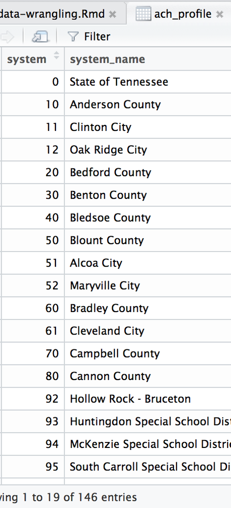

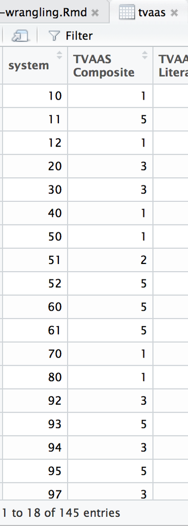

## Combining data frames

We will join the `ach_profile` and `tvaas` data frames using `system` as a key.

A numeric id variable is generally better than a name as a key, because names might be slightly discrepant (e.g.: spelling, capitalization).

## Combining data frames

There are five types of joins:

- `inner_join()` keeps only matched observations.
- `left_join()` drops unmatched observations in the second data frame.
- `right_join()` drops unmatched observations in the first data frame.
- `full_join()` keeps all observations.
- `anti_join()` keeps only unmatched observations in the first data frame.

`ach_profile` has achievement and profile data for all districts and the state. `tvaas` has TVAAS data for all districts.

Q: What happens if we `inner_join()` the `ach_profile` and `tvaas` data frames?

## Combining data frames

There are five types of joins:

- `inner_join()` keeps only matched observations.
- `left_join()` drops unmatched observations in the second data frame.
- `right_join()` drops unmatched observations in the first data frame.
- `full_join()` keeps all observations.
- `anti_join()` keeps only unmatched observations in the first data frame.

`ach_profile` has achievement and profile data for all districts and the state. `tvaas` has TVAAS data for all districts.

Q: What happens if we `left_join()` the `ach_profile` and `tvaas` data frames?

## Combining data frames

There are five types of joins:

- `inner_join()` keeps only matched observations.
- `left_join()` drops unmatched observations in the second data frame.
- `right_join()` drops unmatched observations in the first data frame.
- `full_join()` keeps all observations.
- `anti_join()` keeps only unmatched observations in the first data frame.

`ach_profile` has achievement and profile data for all districts and the state. `tvaas` has TVAAS data for all districts.

Q: What happens if we `right_join()` the `ach_profile` and `tvaas` data frames?

## Combining data frames

There are five types of joins:

- `inner_join()` keeps only matched observations.
- `left_join()` drops unmatched observations in the second data frame.
- `right_join()` drops unmatched observations in the first data frame.
- `full_join()` keeps all observations.
- `anti_join()` keeps only unmatched observations in the first data frame.

`ach_profile` has achievement and profile data for all districts and the state. `tvaas` has TVAAS data for all districts.

Q: What happens if we `full_join()` the `ach_profile` and `tvaas` data frames?

## Combining data frames

There are five types of joins:

- `inner_join()` keeps only matched observations.
- `left_join()` drops unmatched observations in the second data frame.
- `right_join()` drops unmatched observations in the first data frame.
- `full_join()` keeps all observations.
- `anti_join()` keeps only unmatched observations in the first data frame.

`ach_profile` has achievement and profile data for all districts and the state. `tvaas` has TVAAS data for all districts.

Q: What happens if we `anti_join()` the `ach_profile` and `tvaas` data frames?

## Combining data frames

We will join the `ach_profile` and `tvaas` data frames using `system` as a key.

```r
full_join(ach_profile, tvaas, by = "system")
```

The first two arguments to any `join` function are two data frames, and the third is the key variable(s).

## Combining data frames

We will join the `ach_profile` and `tvaas` data frames using `system` as a key.

```
## # A tibble: 147 x 31
##    system        system_name  AlgI AlgII  BioI Chemistry   ELA
##     <int>              <chr> <dbl> <dbl> <dbl>     <dbl> <dbl>
##  1      0 State of Tennessee  70.0  54.3  65.3      44.2  48.4
##  2     10    Anderson County  76.1  63.3  73.6      41.0  45.7
##  3     11       Clinton City    NA    NA    NA        NA  58.3
##  4     12     Oak Ridge City  76.9  72.0  83.5      80.9  56.1
##  5     20     Bedford County  64.3  42.4  62.1      32.5  44.1
##  6     30      Benton County  73.7  58.4  77.1      33.1  46.0
##  7     40     Bledsoe County  64.8  73.9  73.0      19.5  35.4
##  8     50      Blount County  73.2  59.8  65.1      45.4  46.3
##  9     51         Alcoa City  82.2  76.8  88.0      66.0  50.2
## 10     52     Maryville City  83.8  77.3  92.1      80.4  69.6
## # ... with 137 more rows, and 24 more variables: EngI <dbl>,
## #   EngII <dbl>, EngIII <dbl>, Math <dbl>, Science <dbl>,
## #   Enrollment <int>, Pct_Black <dbl>, Pct_Hispanic <dbl>,
## #   Pct_Native_American <dbl>, Pct_EL <dbl>, Pct_SWD <dbl>,
## #   Pct_ED <dbl>, Per_Pupil_Expenditures <dbl>, Pct_BHN <dbl>,
## #   ACT_Composite <dbl>, Pct_Chronically_Absent <dbl>,
## #   Pct_Suspended <dbl>, Pct_Expelled <dbl>, Graduation <dbl>,
## #   Dropout <dbl>, CORE_region <chr>, `TVAAS Composite` <dbl>,
## #   `TVAAS Literacy` <dbl>, `TVAAS Numeracy` <dbl>
```

## Combining data frames

When joining on multiple key variables, specify them as a character vector:

```r
full_join(df1, df2, by = c("key_var1", "key_var2"))
```

## Combining data frames

Key variable names don’t have to match between the two data frame:

```r
full_join(df1, df2, by = c("x1" = "x2", "y1" = "y2", "z1" = "z2"))
```

This will join `df1` and `df2` by matching values of `x1` in `df1` with values of `x2` in `df2`, `y1` with `y2`, and `z1` with `z2`.

## Exercise 10

Create a data frame with the number of districts at each TVAAS level, by CORE region.

```r
ach_profile %>%
    inner_join(tvaas, by = "system") %>%
    mutate(Level1 = if_else(`TVAAS Composite` == 1, 1, 0),
           Level2 = if_else(`TVAAS Composite` == 2, 1, 0),
           Level3 = if_else(`TVAAS Composite` == 3, 1, 0),
           Level4 = if_else(`TVAAS Composite` == 4, 1, 0),
           Level5 = if_else(`TVAAS Composite` == 5, 1, 0)) %>%
    group_by(CORE_region) %>%
    summarise(Level1 = sum(Level1, na.rm = TRUE),
              Level2 = sum(Level2, na.rm = TRUE),
              Level3 = sum(Level3, na.rm = TRUE),
              Level4 = sum(Level4, na.rm = TRUE),
              Level5 = sum(Level5, na.rm = TRUE)) %>%
    ungroup()
```

## Exercise 10

Create a data frame with the number of districts at each TVAAS level, by CORE region.

```r
ach_profile %>%
    inner_join(tvaas, by = "system") %>%
    mutate(Level1 = `TVAAS Composite` == 1,
           Level2 = `TVAAS Composite` == 2,
           Level3 = `TVAAS Composite` == 3,
           Level4 = `TVAAS Composite` == 4,
           Level5 = `TVAAS Composite` == 5) %>%
    group_by(CORE_region) %>%
    summarise(Level1 = sum(Level1, na.rm = TRUE),
              Level2 = sum(Level2, na.rm = TRUE),
              Level3 = sum(Level3, na.rm = TRUE),
              Level4 = sum(Level4, na.rm = TRUE),
              Level5 = sum(Level5, na.rm = TRUE)) %>%
    ungroup()
```

## Exercise 10

Create a data frame with the number of districts at each TVAAS level, by CORE region.

```
## # A tibble: 8 x 6
##              CORE_region Level1 Level2 Level3 Level4 Level5
##                    <chr>  <int>  <int>  <int>  <int>  <int>
## 1           East TN CORE     11      1      4      1      5
## 2          First TN CORE      9      0      3      0      5
## 3    Mid Cumberland CORE      3      2      5      0      6
## 4         Northwest CORE      4      1      6      1     10
## 5     South Central CORE      4      3      4      1      4
## 6         Southeast CORE      6      0      4      1      3
## 7 Southwest/Memphis CORE      7      0      2      0     11
## 8  Upper Cumberland CORE      7      1      4      2      3
```

## Exercise 10

More succinctly:

```
## # A tibble: 34 x 3
##            CORE_region `TVAAS Composite`     n
##                  <chr>             <dbl> <int>
##  1        East TN CORE                 1    11
##  2        East TN CORE                 2     1
##  3        East TN CORE                 3     4
##  4        East TN CORE                 4     1
##  5        East TN CORE                 5     5
##  6       First TN CORE                 1     9
##  7       First TN CORE                 3     3
##  8       First TN CORE                 5     5
##  9 Mid Cumberland CORE                 1     3
## 10 Mid Cumberland CORE                 2     2
## # ... with 24 more rows
```

## `dplyr` and `tidyr`

Your two-stop shop for data wrangling:

`dplyr`: pliers, for data frames

`tidyr`: for reshaping data frames

## Some terminology

A data frame is **wide** by a variable if values of that variable are spread across **columns**.

A data frame is **long** by a variable if values of that variable are spread across **rows**.

## Some terminology

Q: What is the `ach_profile` data frame wide by? Long by?

## Reshaping data frames

`tidyr` has two functions for reshaping:

- `gather()` converts a data frame from wide to long.
- `spread()` converts a data frame from long to wide.

## Reshaping data frames

Suppose I want to reshape this data frame long by subject/characteristic.

## Reshaping data frames

This creates a new variable with `"AlgI"`, `"AlgII"`, …, `"Dropout"`, and a new variable with the appropriate value for each district.

```
## # A tibble: 3,650 x 4
##    system        system_name outcome value
##     <int>              <chr>   <chr> <dbl>
##  1      0 State of Tennessee    AlgI  70.0
##  2     10    Anderson County    AlgI  76.1
##  3     11       Clinton City    AlgI    NA
##  4     12     Oak Ridge City    AlgI  76.9
##  5     20     Bedford County    AlgI  64.3
##  6     30      Benton County    AlgI  73.7
##  7     40     Bledsoe County    AlgI  64.8
##  8     50      Blount County    AlgI  73.2
##  9     51         Alcoa City    AlgI  82.2
## 10     52     Maryville City    AlgI  83.8
## # ... with 3,640 more rows
```

## Reshaping data frames

`gather()` converts a data frame from wide to long:

```r
gather(ach_profile, outcome, value, AlgI:Dropout)
```

- The first argument to `gather()` is a data frame.
- The second is the name of a new variable which will take the values of your column names.
- The third is the name of a new variable which will take the values of the data in your columns.
- The fourth is the columns you want to convert to a variable.

## Reshaping data frames

`gather()` converts a data frame from wide to long:

```r
gather(ach_profile, outcome, value, AlgI:Dropout)
```

```
## # A tibble: 3,650 x 5
##    system        system_name outcome value           CORE_region
##     <int>              <chr>   <chr> <dbl>                 <chr>
##  1      0 State of Tennessee    AlgI  70.0                  <NA>
##  2     10    Anderson County    AlgI  76.1          East TN CORE
##  3     11       Clinton City    AlgI    NA          East TN CORE
##  4     12     Oak Ridge City    AlgI  76.9          East TN CORE
##  5     20     Bedford County    AlgI  64.3    South Central CORE
##  6     30      Benton County    AlgI  73.7        Northwest CORE
##  7     40     Bledsoe County    AlgI  64.8 Upper Cumberland CORE
##  8     50      Blount County    AlgI  73.2          East TN CORE
##  9     51         Alcoa City    AlgI  82.2          East TN CORE
## 10     52     Maryville City    AlgI  83.8          East TN CORE
## # ... with 3,640 more rows
```

## Reshaping data frames

`spread()` converts a data frame from long to wide:

```
## # A tibble: 3,650 x 5
##    system        system_name outcome value           CORE_region
##     <int>              <chr>   <chr> <dbl>                 <chr>
##  1      0 State of Tennessee    AlgI  70.0                  <NA>
##  2     10    Anderson County    AlgI  76.1          East TN CORE
##  3     11       Clinton City    AlgI    NA          East TN CORE
##  4     12     Oak Ridge City    AlgI  76.9          East TN CORE
##  5     20     Bedford County    AlgI  64.3    South Central CORE
##  6     30      Benton County    AlgI  73.7        Northwest CORE
##  7     40     Bledsoe County    AlgI  64.8 Upper Cumberland CORE
##  8     50      Blount County    AlgI  73.2          East TN CORE
##  9     51         Alcoa City    AlgI  82.2          East TN CORE
## 10     52     Maryville City    AlgI  83.8          East TN CORE
## # ... with 3,640 more rows
```

Suppose I want to reshape this data frame wide by district.

## Reshaping data frames

First, I’ll save the long version of this data frame as an R object.

```r
ach_profile_long <- ach_profile %>%
    gather(outcome, value, AlgI:Dropout) %>%
    select(system_name, outcome, value)
```

## Reshaping data frames

`spread()` converts a data frame from long to wide:

```r
spread(ach_profile_long, system_name, value)
```

- The first argument to `spread()` is a data frame.
- The second is the variable you want to convert your data frame wide by. The values of that variable will become column headers.
- The third is the values that will populate the cells in your new columns.

## Reshaping data frames

`spread()` converts a data frame from long to wide:

```
## # A tibble: 25 x 147
##          outcome `Achievement School District` `Alamo City`
##  *         <chr>                         <dbl>        <dbl>
##  1 ACT_Composite                          14.2           NA
##  2          AlgI                          34.0           NA
##  3         AlgII                          20.4           NA
##  4          BioI                          20.6           NA
##  5     Chemistry                           4.5           NA
##  6       Dropout                          27.6           NA
##  7           ELA                          14.3         53.5
##  8          EngI                          37.8           NA
##  9         EngII                          33.0           NA
## 10        EngIII                           8.2           NA
## # ... with 15 more rows, and 144 more variables: `Alcoa
## #   City` <dbl>, `Alvin C. York Institute` <dbl>, `Anderson
## #   County` <dbl>, `Arlington City` <dbl>, `Athens City` <dbl>,
## #   `Bartlett City` <dbl>, `Bedford County` <dbl>, `Bells
## #   City` <dbl>, `Benton County` <dbl>, `Bledsoe County` <dbl>,
## #   `Blount County` <dbl>, `Bradford Special School
## #   District` <dbl>, `Bradley County` <dbl>, `Bristol
## #   City` <dbl>, `Campbell County` <dbl>, `Cannon County` <dbl>,
## #   `Carter County` <dbl>, `Cheatham County` <dbl>, `Chester
## #   County` <dbl>, `Claiborne County` <dbl>, `Clay
## #   County` <dbl>, `Cleveland City` <dbl>, `Clinton City` <dbl>,
## #   `Cocke County` <dbl>, `Coffee County` <dbl>, `Collierville
## #   City` <dbl>, `Crockett County` <dbl>, `Cumberland
## #   County` <dbl>, `Davidson County` <dbl>, `Dayton City` <dbl>,
## #   `Decatur County` <dbl>, `DeKalb County` <dbl>, `Dickson
## #   County` <dbl>, `Dyer County` <dbl>, `Dyersburg City` <dbl>,
## #   `Elizabethton City` <dbl>, `Etowah City` <dbl>, `Fayette
## #   County` <dbl>, `Fayetteville City` <dbl>, `Fentress
## #   County` <dbl>, `Franklin County` <dbl>, `Franklin Special
## #   School District` <dbl>, `Germantown City` <dbl>, `Gibson
## #   County Special School District` <dbl>, `Giles County` <dbl>,
## #   `Grainger County` <dbl>, `Greene County` <dbl>, `Greeneville
## #   City` <dbl>, `Grundy County` <dbl>, `Hamblen County` <dbl>,
## #   `Hamilton County` <dbl>, `Hancock County` <dbl>, `Hardeman
## #   County` <dbl>, `Hardin County` <dbl>, `Hawkins
## #   County` <dbl>, `Haywood County` <dbl>, `Henderson
## #   County` <dbl>, `Henry County` <dbl>, `Hickman County` <dbl>,
## #   `Hollow Rock - Bruceton` <dbl>, `Houston County` <dbl>,
## #   `Humboldt City` <dbl>, `Humphreys County` <dbl>, `Huntingdon
## #   Special School District` <dbl>, `Jackson County` <dbl>,
## #   `Jackson-Madison County` <dbl>, `Jefferson County` <dbl>,
## #   `Johnson City` <dbl>, `Johnson County` <dbl>, `Kingsport
## #   City` <dbl>, `Knox County` <dbl>, `Lake County` <dbl>,
## #   `Lakeland City` <dbl>, `Lauderdale County` <dbl>, `Lawrence
## #   County` <dbl>, `Lebanon Special School District` <dbl>,
## #   `Lenoir City` <dbl>, `Lewis County` <dbl>, `Lexington
## #   City` <dbl>, `Lincoln County` <dbl>, `Loudon County` <dbl>,
## #   `Macon County` <dbl>, `Manchester City` <dbl>, `Marion
## #   County` <dbl>, `Marshall County` <dbl>, `Maryville
## #   City` <dbl>, `Maury County` <dbl>, `McKenzie Special School
## #   District` <dbl>, `McMinn County` <dbl>, `McNairy
## #   County` <dbl>, `Meigs County` <dbl>, `Milan Special School
## #   District` <dbl>, `Millington City` <dbl>, `Monroe
## #   County` <dbl>, `Montgomery County` <dbl>, `Moore
## #   County` <dbl>, `Morgan County` <dbl>, `Murfreesboro
## #   City` <dbl>, `Newport City` <dbl>, `Oak Ridge City` <dbl>,
## #   ...
```

## Exercise 11

Reshape the `tvaas` data frame long by subject, then arrange by system.

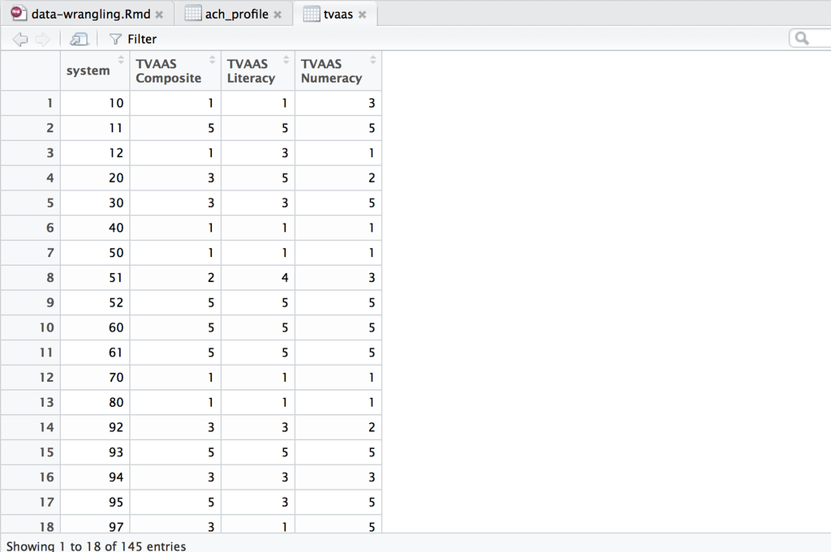

## Exercise 11

Reshape the `tvaas` data frame long by subject, then arrange by system.

```r
tvaas %>%
    gather(subject, score, `TVAAS Composite`:`TVAAS Numeracy`) %>%
    arrange(system)
```

```
## # A tibble: 435 x 3
##    system         subject score
##     <int>           <chr> <dbl>
##  1     10 TVAAS Composite     1
##  2     10  TVAAS Literacy     1
##  3     10  TVAAS Numeracy     3
##  4     11 TVAAS Composite     5
##  5     11  TVAAS Literacy     5
##  6     11  TVAAS Numeracy     5
##  7     12 TVAAS Composite     1
##  8     12  TVAAS Literacy     3
##  9     12  TVAAS Numeracy     1
## 10     20 TVAAS Composite     3
## # ... with 425 more rows
```

## Resources

- The online book **R for Data Science**: http://r4ds.had.co.nz/
- RStudio cheat sheets: https://www.rstudio.com/resources/cheatsheets/
- The Datacamp `dplyr` course: https://www.datacamp.com/courses/dplyr-data-manipulation-r-tutorial